# 36-464 Final DA

Amrith Deepak

May 1, 2016

Part a)

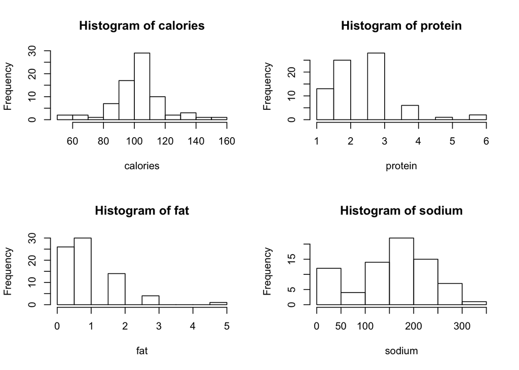

```r
setwd("~/Desktop")
cereal = read.csv("cereal.csv")
cereal$carbo[56]=0
cereal$sugars[56]=0
cereal$potass[4]=0
cereal$potass[20]=0
calories=cereal$calories
protein=cereal$protein
fat=cereal$fat
sodium=cereal$sodium
fiber=cereal$fiber
carbo=cereal$carbo
sugars=cereal$sugars
potass=cereal$potass
vitamins=cereal$vitamins
rating=cereal$rating
par(mfrow=c(2,2))
hist(calories)
hist(protein)
hist(fat)
hist(sodium)
```

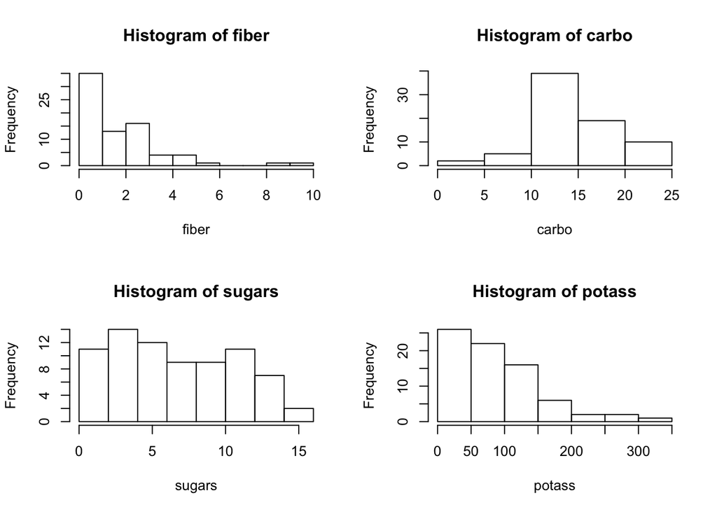

```r
hist(fiber)
hist(carbo)
hist(sugars)
hist(potass)
```

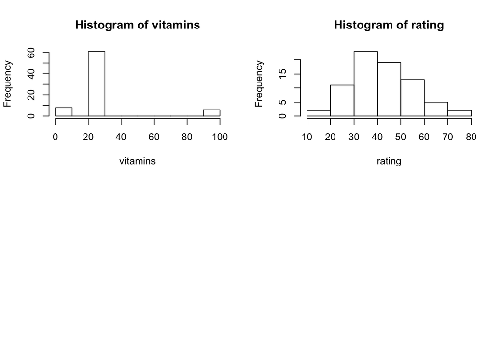

```r
hist(vitamins)
hist(rating)
par(mfrow=c(1,1))
```

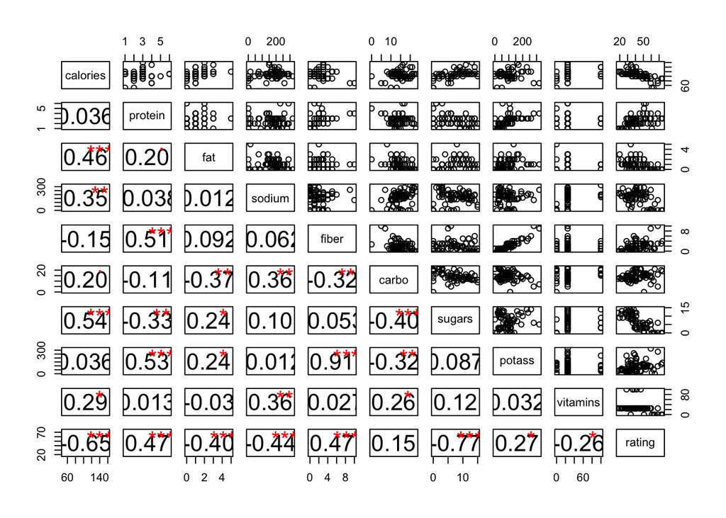

```r
source("panelfxns.R")
pairs(cereal[,2:11], lower.panel=panel.cor)
```

The distribution of calories is approximately symmetric with mean around 107 with values between 50 and 160. There are no apparent outliers.

The distribution of protein is right skewed with mean around 2.5 with values between 1 and 6. There are no apparent outliers, but most values are 1, 2, or 3.

The distribution of sodium is left truncated with mean around 160 with values between 0 and 320. There are no apparent outliers.

The distribution of fiber is right skewed with mean around 2 with values between 0 and 10. There are no apparent outliers, but most values are 0, 1, 2, 3, 4, or 5.

The distribution of carbo is left skewed with mean around 15 with values between 0 and 23. There are no apparent outliers, but most values are between 5 and 20.

The distribution of sugars is approximately uniform with mean around 7 with values between 0 and 15. There are no apparent outliers.

The distribution of potass is right skewed with mean around 92 with values between 0 and 320. There are no apparent outliers.

Vitamins has 3 values, 0, 25, and 100 and most obsevations have value 25.

The distribution of rating is slightly right skewed with mean around 42 with values between 18.04 and 74.47. There are no apparent outliers.

There is a significant positive correlation between protein and rating and fiber and rating, and a significant negative correlation between calories and rating, fat and rating, and sugars and rating. Other significant positive correlations include calories and fat, sodium, and sugars, protein and fiber, protein and potassium, fiber and potassium. A significant negative correlation is sugars and carbohydrates.

Part b)

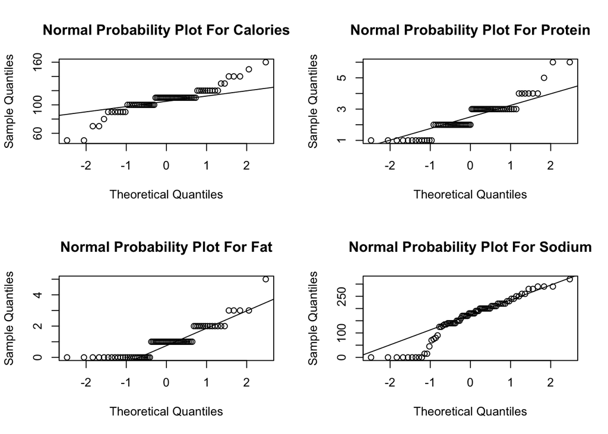

```r
par(mfrow=c(2,2))
qqnorm(calories,main="Normal Probability Plot For Calories")
qqline(calories)
qqnorm(protein,main="Normal Probability Plot For Protein")
qqline(protein)
qqnorm(fat,main="Normal Probability Plot For Fat")
qqline(fat)
qqnorm(sodium,main="Normal Probability Plot For Sodium")
qqline(sodium)
```

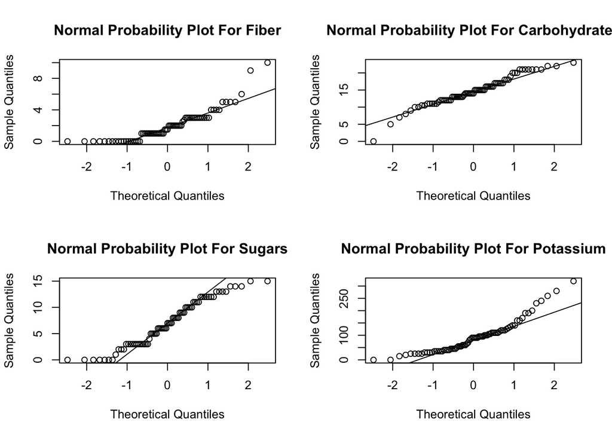

```r
qqnorm(fiber,main="Normal Probability Plot For Fiber")
qqline(fiber)
qqnorm(carbo,main="Normal Probability Plot For Carbohydrates")
qqline(carbo)
qqnorm(sugars,main="Normal Probability Plot For Sugars")
qqline(sugars)
qqnorm(potass,main="Normal Probability Plot For Potassium")
qqline(potass)
```

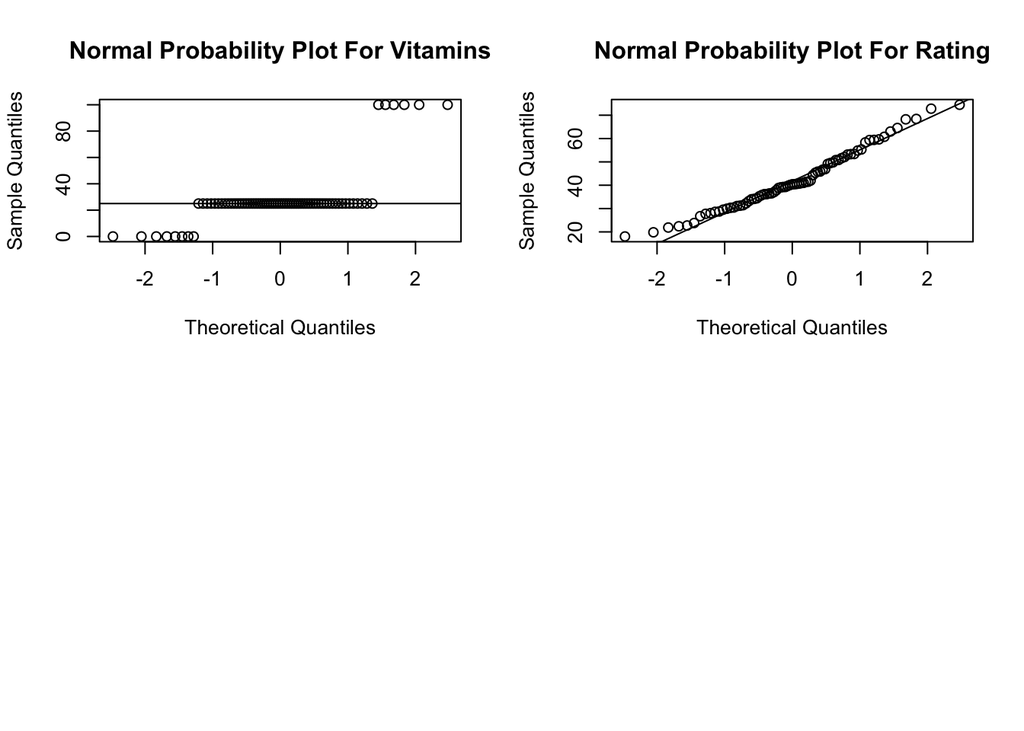

```r
qqnorm(vitamins,main="Normal Probability Plot For Vitamins")
qqline(vitamins)
qqnorm(rating,main="Normal Probability Plot For Rating")
qqline(rating)
par(mfrow=c(1,1))
```

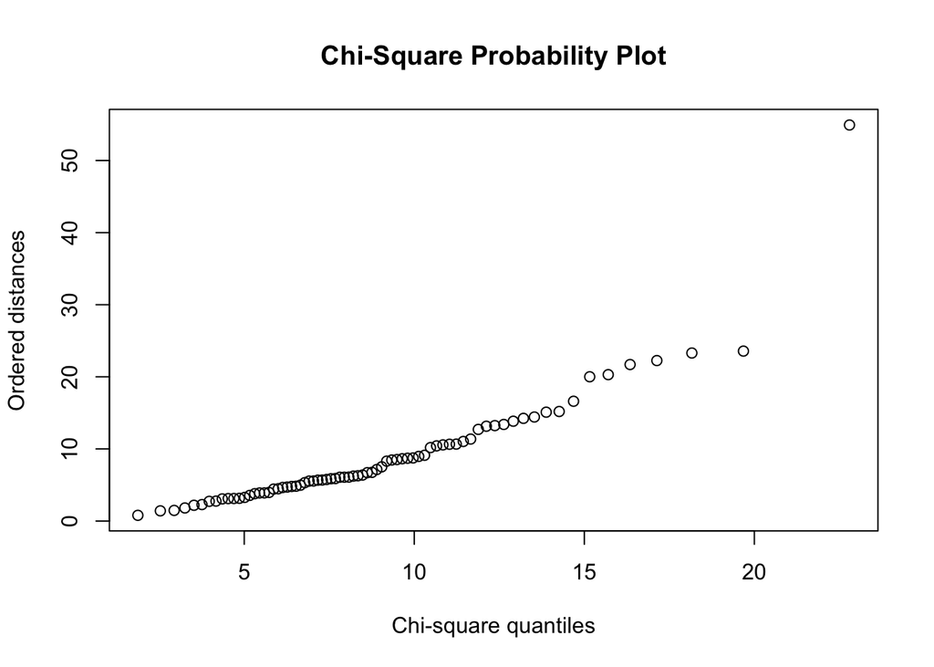

```r
# From hw 3 solution
cereal2=as.matrix(cereal[,2:10])
cereal2.mean<-apply(cereal2, 2, mean); cereal2.cov<-cov(cereal2)
p <- ncol(cereal2); n <- nrow(cereal2)
d <- NULL
for (i in 1:n)
{
d<-c(d, t(cereal2[i,]-cereal2.mean)%*% solve(cereal2.cov)%*% (cereal2[i,]- cereal2.mean))
}
d <- sort(d) #Order the squared distances from smallest to largest
# Compute quantiles of a chi-square distribution
q <- NULL
for (i in 1:n)
{
q <- c(q, qchisq((i-0.5)/n, p))
}
plot(q, d, type="p", xlab="Chi-square quantiles",
ylab="Ordered distances", main="Chi-Square Probability Plot")
```

The variables individually are approximately normal based on the QQplots although some of the variables are slightly skewed. The right skew of fat, protein, and potassium, and the left skew of carbohydates shows in these plots. The left truncation of sodium is also evident. These also show in the histograms.

We dont have evidence to reject the assumption of bivariate normality because none of the scatterplots between variables seems to show a non-linear(curved) pattern.

If the observations come from a multivariate normal distribution, the chi-square plot should display a straight line pattern. Most points in the above figure fall on a straight line. There is an outlier which corresponds to 100%_Bran.

Hence, we don’t have significant evidence against multivariate normality.

Part c)

```r
# code from lecture 16
cereal.new<-(cereal[,c(2:10)])
cereal.new<-scale(cereal.new,center=TRUE, scale=TRUE)
pca.rating<-princomp(cereal.new,loadings=TRUE);summary(pca.rating,loadings=TRUE);
```

```
## Importance of components:
##                           Comp.1    Comp.2    Comp.3    Comp.4     Comp.5
## Standard deviation     1.5994604 1.4328411 1.2771085 0.9722419 0.79947616
## Proportion of Variance 0.2880939 0.2311975 0.1836719 0.1064476 0.07197772
## Cumulative Proportion  0.2880939 0.5192914 0.7029632 0.8094108 0.88138849
##                            Comp.6     Comp.7     Comp.8      Comp.9
## Standard deviation     0.72961337 0.62411810 0.27768818 0.233024546
## Proportion of Variance 0.05994771 0.04386525 0.00868364 0.006114914
## Cumulative Proportion  0.94133620 0.98520145 0.99388509 1.000000000
##
## Loadings:
##          Comp.1 Comp.2 Comp.3 Comp.4 Comp.5 Comp.6 Comp.7 Comp.8 Comp.9
## calories         0.611         0.263         0.475        -0.401  0.399
## protein   0.410        -0.344  0.415  0.174        -0.669  0.125 -0.209
## fat       0.239  0.376  0.230  0.566        -0.366  0.454  0.122 -0.257
## sodium   -0.149  0.358 -0.405 -0.129 -0.554 -0.571 -0.186
## fiber     0.546        -0.207 -0.281 -0.152         0.247 -0.583 -0.382
## carbo    -0.366        -0.521  0.171 -0.155  0.438  0.324  0.278 -0.409
## sugars           0.484  0.410 -0.402         0.223 -0.272  0.286 -0.474
## potass    0.555        -0.184 -0.214 -0.133  0.160  0.241  0.557  0.438
## vitamins -0.100  0.331 -0.385 -0.325  0.762 -0.190
```

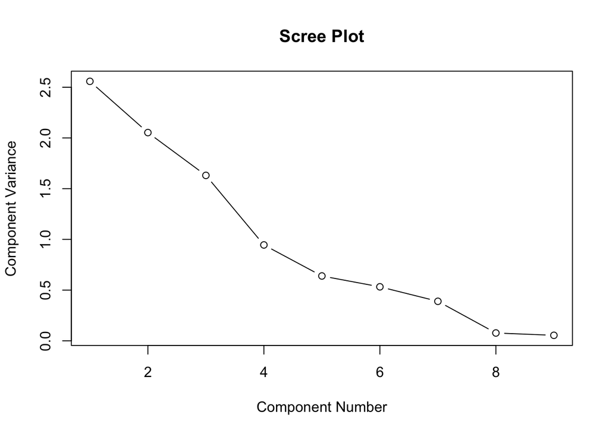

```r
plot(pca.rating$sdev^2, xlab="Component Number", ylab="Component Variance",
type="b", main="Scree Plot")
```

Part d)

```r
cereal_reg<-lm(rating~pca.rating$scores[,1:3], data=as.data.frame(cereal.new))
summary(cereal_reg)
```

```
##
## Call:
## lm(formula = rating ~ pca.rating$scores[, 1:3], data = as.data.frame(cereal.new))
##
## Residuals:
##     Min      1Q  Median      3Q     Max
## -9.0664 -2.3055 -0.3556  1.9534  7.3830
##
## Coefficients:
##                                Estimate Std. Error t value Pr(>|t|)
## (Intercept)                     42.0589     0.4018  104.68   <2e-16 ***
## pca.rating$scores[, 1:3]Comp.1   2.7543     0.2512   10.96   <2e-16 ***
## pca.rating$scores[, 1:3]Comp.2  -7.2963     0.2804  -26.02   <2e-16 ***
## pca.rating$scores[, 1:3]Comp.3  -3.8587     0.3146  -12.27   <2e-16 ***
## ---
## Signif. codes:  0 '***' 0.001 '**' 0.01 '*' 0.05 '.' 0.1 ' ' 1
##
## Residual standard error: 3.479 on 71 degrees of freedom
## Multiple R-squared:  0.9303, Adjusted R-squared:  0.9274
## F-statistic: 315.9 on 3 and 71 DF,  p-value: < 2.2e-16
```

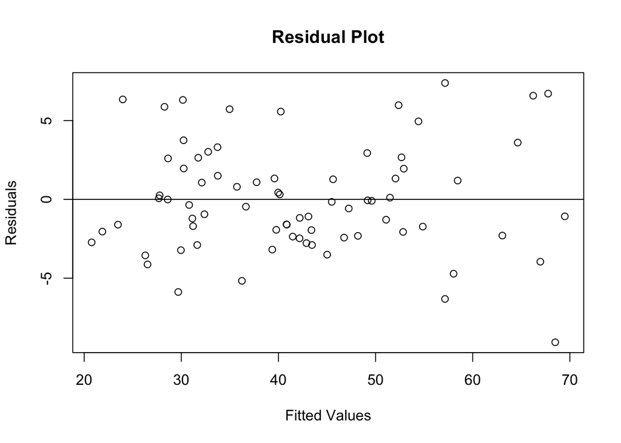

```r
plot(cereal_reg$fit,cereal_reg$residuals, main = "Residual Plot", ylab="Residuals", xlab= "Fitted Values")
abline(0,0)
```

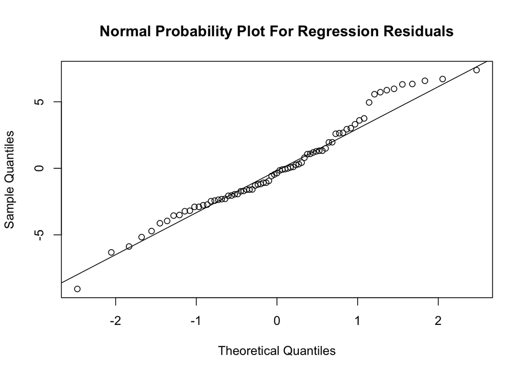

```r
qqnorm(cereal_reg$residuals,main="Normal Probability Plot For Regression Residuals")
qqline(cereal_reg$residuals)
```

The residual plot suggests that the linearity, expectation zero, and constant variance assumptions are roughly met. The qqplot suggests that the normality assumption is met.

2. The second principal component is most significant as it has the highest coefficient in the linear regression. 92.74 % of the variance is explained by the linear regression. All three principal components are significant. This model has a reasonably good fit as the linearlity, expectation zero, constant variance, and normality assumptions have been met. The mean squared error is 12.103 which is reasonably small given that the range of rating values is from 18.04 to 74.47. Also more than 90% of the variance is explained by the linear regression, which is very good.

```r
cereal_reg<-lm(rating~calories+protein+fat+sodium+fiber+carbo+sugars+potass+vitamins,data=cereal)
summary(cereal_reg)
```

```
##
## Call:
## lm(formula = rating ~ calories + protein + fat + sodium + fiber +
##     carbo + sugars + potass + vitamins, data = cereal)
##
## Residuals:
##       Min        1Q    Median        3Q       Max
## -0.087821 -0.011745 -0.000287  0.010603  0.052252
##
## Coefficients:
##               Estimate Std. Error t value Pr(>|t|)
## (Intercept)  5.486e+01  1.982e-02  2768.0   <2e-16 ***
## calories    -2.262e-01  3.485e-04  -649.0   <2e-16 ***
## protein      3.285e+00  3.838e-03   855.9   <2e-16 ***
## fat         -1.658e+00  4.323e-03  -383.5   <2e-16 ***
## sodium      -5.451e-02  3.646e-05 -1494.9   <2e-16 ***
## fiber        3.454e+00  3.633e-03   950.7   <2e-16 ***
## carbo        1.110e+00  1.386e-03   801.2   <2e-16 ***
## sugars      -7.090e-01  1.446e-03  -490.4   <2e-16 ***
## potass      -3.423e-02  1.114e-04  -307.1   <2e-16 ***
## vitamins    -5.130e-02  1.299e-04  -395.1   <2e-16 ***
## ---
## Signif. codes:  0 '***' 0.001 '**' 0.01 '*' 0.05 '.' 0.1 ' ' 1
##
## Residual standard error: 0.02263 on 65 degrees of freedom
## Multiple R-squared:      1,  Adjusted R-squared:      1
## F-statistic: 2.676e+06 on 9 and 65 DF,  p-value: < 2.2e-16
```

One advantage of the linear regression model is that it has principal components, so there are fewer coefficients, making it simpler. A disadvantage of the linear regression model is that it doesn’t include all the variables, which makes it more difficult to interpret, especially when the principal components aren’t clear. An advantage of the multiple linear regression model is that it’s easier to interpret, and it includes all the variables, not just a set of variables that account for a certain percentage of variation. A disadvantage of this model is that the multiple regression model may give multiple weights to collinear variables.

Part e)

```r
# from hw 8
sapply(1:5, function(f) factanal(cereal.new, factors = f, method ="mle")$PVAL)
```

```
##    objective    objective    objective    objective    objective
## 1.251755e-30 7.996820e-20 5.845989e-10 6.865404e-02 6.973278e-02
```

```r
factanal(cereal.new, factors=3, method="mle",rotation="varimax")
```

```
##
## Call:
## factanal(x = cereal.new, factors = 3, rotation = "varimax", method = "mle")
##
## Uniquenesses:
## calories  protein      fat   sodium    fiber    carbo   sugars   potass
##    0.005    0.693    0.567    0.784    0.084    0.005    0.413    0.066
## vitamins
##    0.864
##
## Loadings:
##          Factor1 Factor2 Factor3
## calories          0.701   0.709
## protein   0.551
## fat       0.143   0.642
## sodium                    0.464
## fiber     0.948          -0.132
## carbo    -0.237  -0.538   0.806
## sugars            0.765
## potass    0.956   0.138
## vitamins                  0.364
##
##                Factor1 Factor2 Factor3
## SS loadings      2.198   1.802   1.520
## Proportion Var   0.244   0.200   0.169
## Cumulative Var   0.244   0.444   0.613
##
## Test of the hypothesis that 3 factors are sufficient.
## The chi square statistic is 68.6 on 12 degrees of freedom.
## The p-value is 5.85e-10
```

```r
factanal(cereal.new, factors=4, method="mle",rotation="varimax")
```

```
##
## Call:
## factanal(x = cereal.new, factors = 4, rotation = "varimax", method = "mle")
##
## Uniquenesses:
## calories  protein      fat   sodium    fiber    carbo   sugars   potass
##    0.005    0.420    0.419    0.768    0.112    0.005    0.005    0.033
## vitamins
##    0.845
##
## Loadings:
##          Factor1 Factor2 Factor3 Factor4
## calories          0.684   0.320   0.647
## protein   0.533          -0.398   0.367
## fat       0.134           0.109   0.740
## sodium            0.480
## fiber     0.936  -0.103
## carbo    -0.268   0.779  -0.471  -0.307
## sugars            0.139   0.966   0.204
## potass    0.973                   0.114
## vitamins          0.386
##
##                Factor1 Factor2 Factor3 Factor4
## SS loadings      2.204   1.492   1.442   1.250
## Proportion Var   0.245   0.166   0.160   0.139
## Cumulative Var   0.245   0.411   0.571   0.710
##
## Test of the hypothesis that 4 factors are sufficient.
## The chi square statistic is 11.71 on 6 degrees of freedom.
## The p-value is 0.0687
```

```r
factanal(cereal.new, factors=5, method="mle",rotation="varimax")
```

```
##
## Call:
## factanal(x = cereal.new, factors = 5, rotation = "varimax", method = "mle")
##
## Uniquenesses:
## calories  protein      fat   sodium    fiber    carbo   sugars   potass
##    0.154    0.005    0.005    0.752    0.094    0.036    0.005    0.045
## vitamins
##    0.831
##
## Loadings:
##          Factor1 Factor2 Factor3 Factor4 Factor5
## calories          0.690   0.409   0.428   0.105
## protein   0.386          -0.186   0.117   0.893
## fat                       0.138   0.979
## sodium            0.495
## fiber     0.931  -0.108                   0.162
## carbo    -0.257   0.742  -0.527  -0.247
## sugars            0.162   0.955   0.134  -0.195
## potass    0.948                   0.120   0.183
## vitamins          0.403
##
##                Factor1 Factor2 Factor3 Factor4 Factor5
## SS loadings      2.000   1.474   1.425   1.251   0.924
## Proportion Var   0.222   0.164   0.158   0.139   0.103
## Cumulative Var   0.222   0.386   0.544   0.683   0.786
##
## Test of the hypothesis that 5 factors are sufficient.
## The chi square statistic is 3.29 on 1 degree of freedom.
## The p-value is 0.0697
```

An appropriate number of factors here is 4 because with 3 factors, we only get 61.3% of the variance accounted for. With 4 factors, we get 71%, which seems sufficient. With 5, the proportion explained goes up to 78.6%, but interpreting 5 factors doesn’t seem reasonable. The first factor is mostly defined by the fiber and potassium, which are positively correlated with each other and the first factor. The second factor is mostly defined by calories and carbohydrates which are positively correlated with each other and positively correlated with the second factor. The third factor is mostly defined by sugars which are positively correlated with the third factor. The fourth factor is mostly defined by fat which is positively correlated with the fourth factor.

Part f)

In terms of summarizing the covariance/correlation structure, I prefer factor analysis because in principal component analysis, the emphasis is on explaining the total variance, as contrasted with the attempt to explain the covariances/correlations in factor analysis.

In terms of dimension reduction, I prefer principal component analysis because principal component analysis requires essentailly no assumptions, while factor analysis makes several key assumptions. If we change the number of factors, the (estimated) factors change. This does not happen in principal component analysis.

Part g)

```r
rating.categ = ifelse(cereal$rating<36,1,ifelse(cereal$rating<46, 2,3))
```

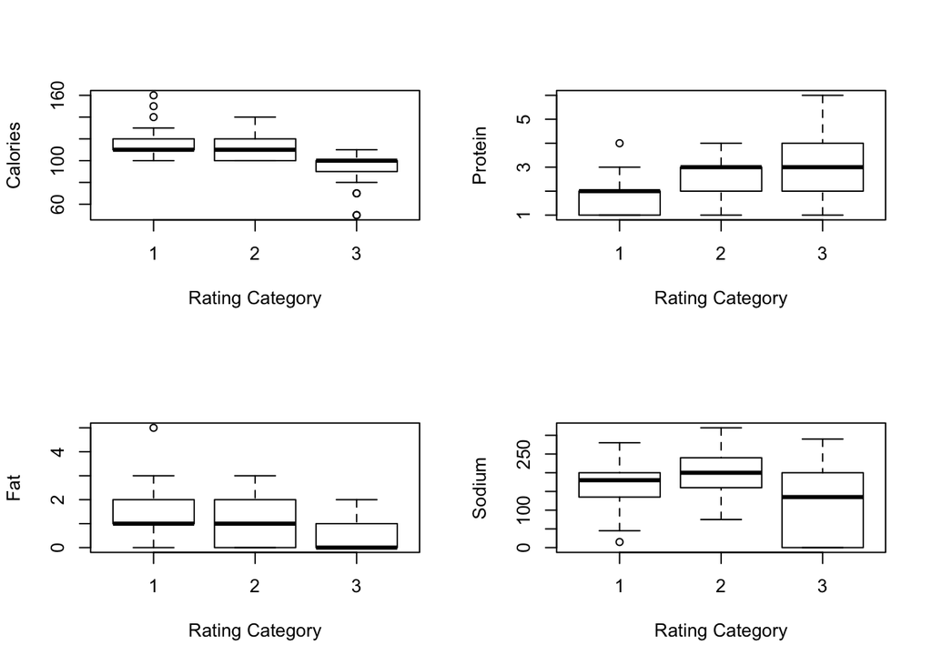

```r
par(mfrow=c(2,2))
boxplot(calories~rating.categ, ylab="Calories",xlab="Rating Category")
boxplot(protein~rating.categ, ylab="Protein",xlab="Rating Category")
boxplot(fat~rating.categ, ylab="Fat",xlab="Rating Category")
boxplot(sodium~rating.categ, ylab="Sodium",xlab="Rating Category")
```

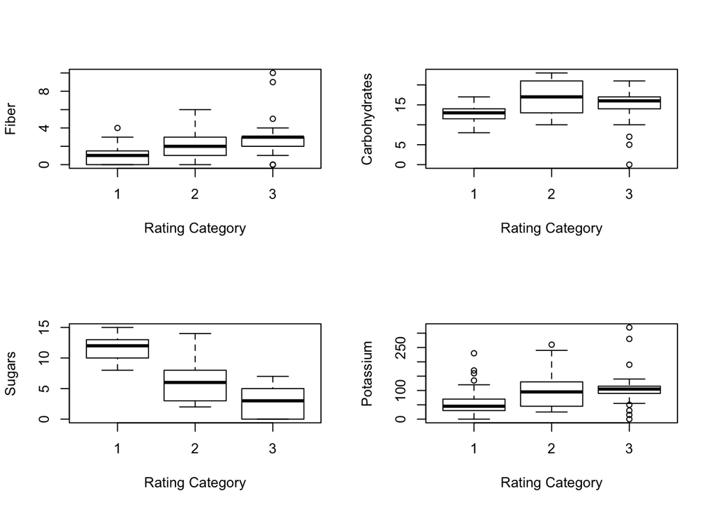

```r
boxplot(fiber~rating.categ, ylab="Fiber",xlab="Rating Category")
boxplot(carbo~rating.categ, ylab="Carbohydrates",xlab="Rating Category")
boxplot(sugars~rating.categ, ylab="Sugars",xlab="Rating Category")
boxplot(potass~rating.categ, ylab="Potassium",xlab="Rating Category")
```

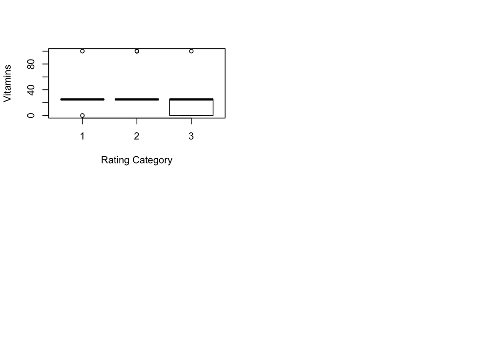

```r
boxplot(vitamins~rating.categ, ylab="Vitamins",xlab="Rating Category")
```

Generally, the cereals with higher rating category seem to have more fiber, protein, and potassium, and tend to have less sugar. High rated cerals seem to also have less fat and calories. Other than that, there are no correlations clearly visible from the boxplot.

```r
fit<-manova(as.matrix(cereal.new)~as.factor(rating.categ))
N=dim(cereal)[1]
E<-(N-1)*cov(fit$residuals)
H<-(N-1)*cov(fit$fitted.values)
T=E+H
summary(fit)
```

```
##                         Df Pillai approx F num Df den Df    Pr(>F)
## as.factor(rating.categ)  2 1.1451   9.6744     18    130 < 2.2e-16 ***
## Residuals               72
## ---
## Signif. codes:  0 '***' 0.001 '**' 0.01 '*' 0.05 '.' 0.1 ' ' 1
```

H$_0$: $\mu_1$ = $\mu_2$ = $\mu_3$ vs H$_a$: at least two of the mean vectors are not the same.

Mean vectors here refer to the rating category.

We reject H$_0$ since the p-value is < 2.2 *10$^{-16}$ which is less than 0.05. We have sufficient evidence to believe that the average amount of nutrition components across different consumer rating categories aren’t the same and that they are different across atleast 2 consumer rating categories.

(iv, v)

NOTE: Part iv and v are done together.

```r
summary.aov(fit)
```

```
##  Response calories :
##                         Df Sum Sq Mean Sq F value    Pr(>F)
## as.factor(rating.categ)  2 28.842 14.4212  22.993 1.897e-08 ***
## Residuals               72 45.158  0.6272
## ---
## Signif. codes:  0 '***' 0.001 '**' 0.01 '*' 0.05 '.' 0.1 ' ' 1
##
##  Response protein :
##                         Df Sum Sq Mean Sq F value    Pr(>F)
## as.factor(rating.categ)  2 18.585  9.2927  12.074 3.007e-05 ***
## Residuals               72 55.415  0.7696
## ---
## Signif. codes:  0 '***' 0.001 '**' 0.01 '*' 0.05 '.' 0.1 ' ' 1
##
##  Response fat :
##                         Df Sum Sq Mean Sq F value   Pr(>F)
## as.factor(rating.categ)  2   9.62  4.8100  5.3793 0.006648 **
## Residuals               72  64.38  0.8942
## ---
## Signif. codes:  0 '***' 0.001 '**' 0.01 '*' 0.05 '.' 0.1 ' ' 1
##
##  Response sodium :
##                         Df Sum Sq Mean Sq F value    Pr(>F)
## as.factor(rating.categ)  2 13.864  6.9320  8.2996 0.0005708 ***
## Residuals               72 60.136  0.8352
## ---
## Signif. codes:  0 '***' 0.001 '**' 0.01 '*' 0.05 '.' 0.1 ' ' 1
##
##  Response fiber :
##                         Df Sum Sq Mean Sq F value    Pr(>F)
## as.factor(rating.categ)  2 13.463  6.7314   8.006 0.0007252 ***
## Residuals               72 60.537  0.8408
## ---
## Signif. codes:  0 '***' 0.001 '**' 0.01 '*' 0.05 '.' 0.1 ' ' 1
##
##  Response carbo :
##                         Df Sum Sq Mean Sq F value   Pr(>F)
## as.factor(rating.categ)  2 11.028  5.5140  6.3046 0.002999 **
## Residuals               72 62.972  0.8746
## ---
## Signif. codes:  0 '***' 0.001 '**' 0.01 '*' 0.05 '.' 0.1 ' ' 1
##
##  Response sugars :
##                         Df Sum Sq Mean Sq F value    Pr(>F)
## as.factor(rating.categ)  2 47.334 23.6670  63.903 < 2.2e-16 ***
## Residuals               72 26.666  0.3704
## ---
## Signif. codes:  0 '***' 0.001 '**' 0.01 '*' 0.05 '.' 0.1 ' ' 1
##
##  Response potass :
##                         Df Sum Sq Mean Sq F value  Pr(>F)
## as.factor(rating.categ)  2  6.345  3.1726  3.3764 0.03966 *
## Residuals               72 67.655  0.9396
## ---
## Signif. codes:  0 '***' 0.001 '**' 0.01 '*' 0.05 '.' 0.1 ' ' 1
##
##  Response vitamins :
##                         Df Sum Sq Mean Sq F value  Pr(>F)
## as.factor(rating.categ)  2  6.375  3.1877  3.3939 0.03903 *
## Residuals               72 67.625  0.9392
## ---
## Signif. codes:  0 '***' 0.001 '**' 0.01 '*' 0.05 '.' 0.1 ' ' 1
```

```r
aov.fat = aov(fat~as.factor(rating.categ))
Tukeycomp.fat<-TukeyHSD(aov.fat, conf.level=1-(0.05)/9)
aov.potass = aov(potass~as.factor(rating.categ))
Tukeycomp.potass<-TukeyHSD(aov.potass, conf.level=1-(0.05)/9)
aov.vitamins = aov(vitamins~as.factor(rating.categ))
Tukeycomp.vitamins<-TukeyHSD(aov.vitamins, conf.level=1-(0.05)/9)
aov.calories = aov(calories~as.factor(rating.categ))
aov.sodium = aov(sodium~as.factor(rating.categ))
Tukeycomp.sodium<-TukeyHSD(aov.sodium, conf.level=1-(0.05)/9)
Tukeycomp.calories<-TukeyHSD(aov.calories, conf.level=1-(0.05)/9)
aov.protein = aov(protein~as.factor(rating.categ))
Tukeycomp.protein<-TukeyHSD(aov.protein, conf.level=1-(0.05)/9)
aov.fiber = aov(fiber~as.factor(rating.categ))
Tukeycomp.fiber<-TukeyHSD(aov.fiber, conf.level=1-(0.05)/9)
aov.carbo = aov(carbo~as.factor(rating.categ))
Tukeycomp.carbo<-TukeyHSD(aov.carbo, conf.level=1-(0.05)/9)
aov.sugars = aov(sugars~as.factor(rating.categ))
Tukeycomp.sugars<-TukeyHSD(aov.sugars, conf.level=1-(0.05)/9)
Tukeycomp.calories
```

```
##   Tukey multiple comparisons of means
##     99.44444% family-wise confidence level
##
## Fit: aov(formula = calories ~ as.factor(rating.categ))
##
## $`as.factor(rating.categ)`
##      diff       lwr        upr     p adj
## 2-1  -4.8 -17.68508   8.085081 0.4593981
## 3-1 -25.6 -38.48508 -12.714919 0.0000000
## 3-2 -20.8 -33.68508  -7.914919 0.0000057
```

```r
Tukeycomp.protein
```

```
##   Tukey multiple comparisons of means
##     99.44444% family-wise confidence level
##
## Fit: aov(formula = protein ~ as.factor(rating.categ))
##
## $`as.factor(rating.categ)`
##     diff        lwr      upr     p adj
## 2-1 0.68 -0.1825536 1.542554 0.0357316
## 3-1 1.32  0.4574464 2.182554 0.0000161
## 3-2 0.64 -0.2225536 1.502554 0.0513147
```

```r
Tukeycomp.fat
```

```
##   Tukey multiple comparisons of means
##     99.44444% family-wise confidence level
##
## Fit: aov(formula = fat ~ as.factor(rating.categ))
##
## $`as.factor(rating.categ)`
##      diff       lwr         upr     p adj
## 2-1 -0.24 -1.087011 0.607010784 0.6359637
## 3-1 -0.84 -1.687011 0.007010784 0.0060110
## 3-2 -0.60 -1.447011 0.247010784 0.0659654
```

```r
Tukeycomp.sodium
```

```
##   Tukey multiple comparisons of means
##     99.44444% family-wise confidence level
##
## Fit: aov(formula = sodium ~ as.factor(rating.categ))
##
## $`as.factor(rating.categ)`
##      diff        lwr       upr     p adj
## 2-1  41.2  -28.99845 111.39845 0.1505845
## 3-1 -47.8 -117.99845  22.39845 0.0804053
## 3-2 -89.0 -159.19845 -18.80155 0.0003464
```

```r
Tukeycomp.fiber
```

```
##   Tukey multiple comparisons of means
##     99.44444% family-wise confidence level
##
## Fit: aov(formula = fiber ~ as.factor(rating.categ))
##
## $`as.factor(rating.categ)`
##      diff        lwr      upr     p adj
## 2-1 1.080 -0.5640179 2.724018 0.0950862
## 3-1 2.048  0.4039821 3.692018 0.0004422
## 3-2 0.968 -0.6760179 2.612018 0.1488115
```

```r
Tukeycomp.carbo
```

```
##   Tukey multiple comparisons of means
##     99.44444% family-wise confidence level
##
## Fit: aov(formula = carbo ~ as.factor(rating.categ))
##
## $`as.factor(rating.categ)`
##      diff        lwr      upr     p adj
## 2-1  3.96  0.3795607 7.540439 0.0019479
## 3-1  1.98 -1.6004393 5.560439 0.1850919
## 3-2 -1.98 -5.5604393 1.600439 0.1850919
```

```r
Tukeycomp.sugars
```

```
##   Tukey multiple comparisons of means
##     99.44444% family-wise confidence level
##
## Fit: aov(formula = sugars ~ as.factor(rating.categ))
##
## $`as.factor(rating.categ)`
##      diff        lwr       upr    p adj
## 2-1 -5.04  -7.462521 -2.617479 0.00e+00
## 3-1 -8.48 -10.902521 -6.057479 0.00e+00
## 3-2 -3.44  -5.862521 -1.017479 6.06e-05
```

```r
Tukeycomp.potass
```

```
##   Tukey multiple comparisons of means
##     99.44444% family-wise confidence level
##
## Fit: aov(formula = potass ~ as.factor(rating.categ))
##
## $`as.factor(rating.categ)`
##     diff       lwr       upr     p adj
## 2-1 36.0 -22.28233  94.28233 0.1237119
## 3-1 44.4 -13.88233 102.68233 0.0440530
## 3-2  8.4 -49.88233  66.68233 0.8888721
```

```r
Tukeycomp.vitamins
```

```
##   Tukey multiple comparisons of means
##     99.44444% family-wise confidence level
##
## Fit: aov(formula = vitamins ~ as.factor(rating.categ))
##
## $`as.factor(rating.categ)`
##     diff        lwr       upr     p adj
## 2-1   10  -9.921163 29.921163 0.2473259
## 3-1   -6 -25.921163 13.921163 0.5999754
## 3-2  -16 -35.921163  3.921163 0.0317147
```

Group 1 refers to low ratings, group 2 to medium ratings, and group 3 to high ratings. The number of calories is greater in group 1 than group 3 and group 2 than group 3. There is more protein in cereals in group 3 than group 1. There is more sodium in cereals in group 2 than group 3. There is more fiber in cereals in group 3 than group 1. There are more carbohydrates in cereals in group 2 than group 1. There are more sugars in cereals in group 1 than group 2 and more sugars in cereals in group 2 than group 3.

We don’t have sufficeint evidence to believe that the fat, potassium, and vitamin content differs between cereals in different categories.

Other than the differences labeled above, we don’t have sufficient evidence that the content of any other nutrients differ between groups not listed above.

The conclusion is trustable, because we used a Tukey comparision and checked that 0 isn’t in the confidence interval. We also saw in the general ANOVA fit that not all nutrient values across all categories are the same, which is supported in the individual aov tests.

Part h)

```r
# Lecture 23
library(MASS)
lda.cereal<-lda(rating.categ~calories+protein+sodium+fat+fiber+carbo+sugars+vitamins+potass, data=as.data.frame(cereal.new))
lda.cereal
```

```
## Call:
## lda(rating.categ ~ calories + protein + sodium + fat + fiber +
##     carbo + sugars + vitamins + potass, data = as.data.frame(cereal.new))
##
## Prior probabilities of groups:
##         1         2         3
## 0.3333333 0.3333333 0.3333333
##
## Group means:
##     calories     protein     sodium        fat       fiber         carbo
## 1  0.5655796 -0.61574118  0.0260091  0.3649658 -0.52809606 -4.696403e-01
## 2  0.2976735  0.01231482  0.5130885  0.1216553  0.01890881  4.696403e-01
## 3 -0.8632530  0.60342636 -0.5390976 -0.4866210  0.50918725  6.880781e-17
##       sugars    vitamins     potass
## 1  1.0280865 -0.05890329 -0.4047718
## 2 -0.1216670  0.38287136  0.1389515
## 3 -0.9064194 -0.32396807  0.2658203
##
## Coefficients of linear discriminants:
##                  LD1         LD2
## calories -0.65381741 -0.05140825
## protein   0.70386737  0.38740942
## sodium   -0.42237207 -0.48404453
## fat      -0.44891993 -0.35044177
## fiber     0.75853279  0.57432938
## carbo     0.47272368 -0.55487822
## sugars   -1.36070772  0.42106031
## vitamins  0.06241978 -0.28391265
## potass    0.13151617 -1.07242876
##
## Proportion of trace:
##    LD1    LD2
## 0.9442 0.0558
```

```r
Region <- (rating.categ); Y <- as.matrix(cereal.new); n <- nrow(Y); p <- ncol(Y)
 proj<- lda.cereal$scaling; Y.t = Y %*% proj
Sigma = matrix(0,p,p)
for (j in 1:3) {
Sigma = Sigma + t(cereal.new)%*%cereal.new
}
Sigma = Sigma/(n-3)
Sigmainv = solve(Sigma)
Sigmainv
```

```
##             calories     protein         fat      sodium       fiber
## calories  1.82667862 -0.62061313 -0.85371401 -0.01331994  0.05925669
## protein  -0.62061313  0.80921952  0.19942169 -0.01171142  0.02616020
## fat      -0.85371401  0.19942169  0.85219686 -0.05004971  0.30043795
## sodium   -0.01331994 -0.01171142 -0.05004971  0.44577810 -0.06324822
## fiber     0.05925669  0.02616020  0.30043795 -0.06324822  2.41081444
## carbo    -1.28918339  0.50991256  0.77564358 -0.20905297  0.33225446
## sugars   -1.50204581  0.79656222  0.67981191 -0.10933646  0.36106218
## potass    0.12751589 -0.38018294 -0.36001089  0.02676994 -2.20020806
## vitamins -0.02750555 -0.03734643  0.02416431 -0.09335412  0.01737893
##               carbo      sugars      potass    vitamins
## calories -1.2891834 -1.50204581  0.12751589 -0.02750555
## protein   0.5099126  0.79656222 -0.38018294 -0.03734643
## fat       0.7756436  0.67981191 -0.36001089  0.02416431
## sodium   -0.2090530 -0.10933646  0.02676994 -0.09335412
## fiber     0.3322545  0.36106218 -2.20020806  0.01737893
## carbo     1.5989962  1.39717321 -0.31541072 -0.10049114
## sugars    1.3971732  1.88210004 -0.56877714 -0.07996809
## potass   -0.3154107 -0.56877714  2.55131228 -0.03998417
## vitamins -0.1004911 -0.07996809 -0.03998417  0.40489810
```

$d_i(y) = \hat{\mu_i}\hat{\Sigma^{-1}}y-1/2\hat{\mu_i}'\hat{\Sigma}^{-1}\hat{\mu_i}+ln \hat{\pi_i}$

The $\hat{\mu_i}$ matrix is given in the group means section of the output.

```
##     calories     protein     sodium        fat       fiber         carbo
## 1  0.5655796 -0.61574118  0.0260091  0.3649658 -0.52809606 -4.696403e-01
## 2  0.2976735  0.01231482  0.5130885  0.1216553  0.01890881  4.696403e-01
## 3 -0.8632530  0.60342636 -0.5390976 -0.4866210  0.50918725  6.880781e-17
##       sugars    vitamins     potass
## 1  1.0280865 -0.05890329 -0.4047718
## 2 -0.1216670  0.38287136  0.1389515
## 3 -0.9064194 -0.32396807  0.2658203
```

The $\hat{\pi_i}$ matrix is given in the Prior probabilities of groups section.

```
##         1         2         3
## 0.3333333 0.3333333 0.3333333
```

The $\hat{\Sigma^{-1}}$ matrix is

```
##             calories     protein         fat      sodium       fiber
## calories  1.82667862 -0.62061313 -0.85371401 -0.01331994  0.05925669
## protein  -0.62061313  0.80921952  0.19942169 -0.01171142  0.02616020
## fat      -0.85371401  0.19942169  0.85219686 -0.05004971  0.30043795
## sodium   -0.01331994 -0.01171142 -0.05004971  0.44577810 -0.06324822
## fiber     0.05925669  0.02616020  0.30043795 -0.06324822  2.41081444
## carbo    -1.28918339  0.50991256  0.77564358 -0.20905297  0.33225446
## sugars   -1.50204581  0.79656222  0.67981191 -0.10933646  0.36106218
## potass    0.12751589 -0.38018294 -0.36001089  0.02676994 -2.20020806
## vitamins -0.02750555 -0.03734643  0.02416431 -0.09335412  0.01737893
##               carbo      sugars      potass    vitamins
## calories -1.2891834 -1.50204581  0.12751589 -0.02750555
## protein   0.5099126  0.79656222 -0.38018294 -0.03734643
## fat       0.7756436  0.67981191 -0.36001089  0.02416431
## sodium   -0.2090530 -0.10933646  0.02676994 -0.09335412
## fiber     0.3322545  0.36106218 -2.20020806  0.01737893
## carbo     1.5989962  1.39717321 -0.31541072 -0.10049114
## sugars    1.3971732  1.88210004 -0.56877714 -0.07996809
## potass   -0.3154107 -0.56877714  2.55131228 -0.03998417
## vitamins -0.1004911 -0.07996809 -0.03998417  0.40489810
```

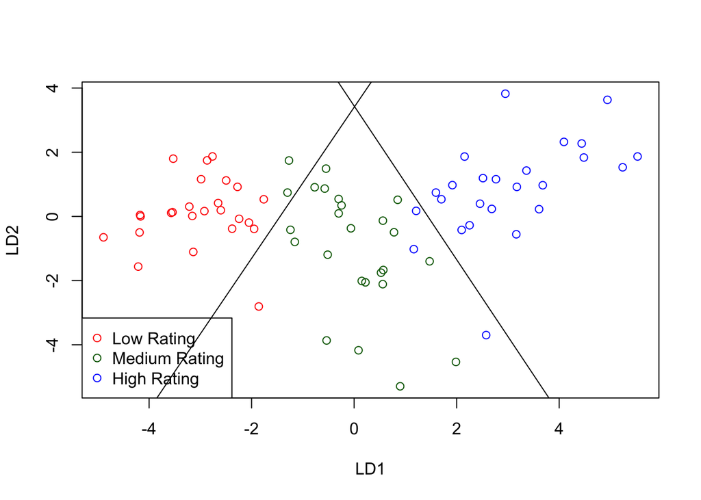

```r
cols = c("red","darkgreen","blue");
# Hw 9 solution
mu = lda.cereal$means %*% proj ;
pi = lda.cereal$prior
getab = function(l,m,mu,pi) {
b = (mu[m,1]-mu[l,1])/(mu[l,2]-mu[m,2])
norml = sum(mu[l,]^2)
normm = sum(mu[m,]^2)
a = (log(pi[m]/pi[l]) + 0.5*(norml-normm))/(mu[l,2]-mu[m,2])
return(list(a=a,b=b))
}
ab12 = getab(1,2,mu,pi) # 1 and 2
ab13 = getab(1,3,mu,pi) # 1 and 3
ab23 = getab(2,3,mu,pi) # 2 and 3
plot(Y.t,col=cols[Region])
legend("bottomleft",pch=21,col=cols, legend=c("Low Rating","Medium Rating","High Rating"))
abline(ab12$a, ab12$b, col="black")
abline(ab23$a, ab23$b, col="black")
```

```r
fit<-predict(lda.cereal)$class
table(rating.categ, fit)
```

```
##             fit
## rating.categ  1  2  3
##            1 24  1  0
##            2  0 25  0
##            3  0  2 23
```

```r
1-sum(diag(table(rating.categ, fit)))/sum(table(rating.categ, fit))
```

```
## [1] 0.04
```

The linear classifier performs well as the APER is 0.04. Also, the linear classifier splits the data very well, as shown in the plot. The boundaries are very clear, as very few points are incorrectly classified.

Part i)

Reducing the dimension of data, and then predicting the actual ratings by a linear regression model is advantageous because you are treating rating as a continuous variable, and you will get an exact value for the predicted rating. One disadvantage is that you are using principal components that account for a certain percent of variance, and not the exact variables. Categorizing the ratings, and then using the nutritional informations to build a linear classifier for ratings is advantageous since you are discretizing into categories, and making the model simpler. You are just trying to group it into a category, which is less complex. However, a disadvantage is that you won’t get an exact rating value prediction. Another advantage here is that you are using all the variables, rather than principal components.

Part j)

```r
predict(lda.cereal,newdata=data.frame(calories=150,protein=4,fat=3,sodium=95,fiber=3,carbo=16,sugars=11,potass=170,vitamins=25))$class
```

```
## [1] 1
## Levels: 1 2 3
```

```r
cereal_reg_multiple=lm(rating~calories+protein+fat+sodium+fiber+carbo+sugars+potass+vitamins, data=cereal)
predict(cereal_reg_multiple, newdata = data.frame(calories=150,protein=4,fat=3,sodium=95,fiber=3,carbo=16,sugars=11,potass=170,vitamins=25))
```

```
##        1
## 37.15049
```